# 5 - Conversion to and from tidytext_SOLVED

## Spam and ham exercise

Recreate the trip around the formats with this dataset of [spam and ham messages from Kaggle](https://www.kaggle.com/datasets/team-ai/spam-text-message-classification). Some of them are ham (real interesting messages) and some of them are spam. Follow the steps:

1. Read it with the `readtext()` function from quanteda. `View()` the dataset to have a look.

```r
library(readtext)

spam <- readtext("spam.csv")
spam
```

```
## readtext object consisting of 5572 documents and 1 docvar.
## # A data frame: 5,572 × 3
##   doc_id     text          Message
##   <chr>      <chr>         <chr>
## 1 spam.csv.1 "\"ham\"..."  Go until jurong point, crazy.. Available only in bug…
## 2 spam.csv.2 "\"ham\"..."  Ok lar... Joking wif u oni...
## 3 spam.csv.3 "\"spam\"..." Free entry in 2 a wkly comp to win FA Cup final tkts…
## 4 spam.csv.4 "\"ham\"..."  U dun say so early hor... U c already then say...
## 5 spam.csv.5 "\"ham\"..."  Nah I don't think he goes to usf, he lives around he…
## 6 spam.csv.6 "\"spam\"..." FreeMsg Hey there darling it's been 3 week's now and…
## # ℹ 5,566 more rows
```

2. Change the name of the “text” column to “label”.

```r
colnames(spam)[colnames(spam) == "text"] <- "label"
spam
```

```
## readtext object consisting of 5572 documents and 1 docvar.
## # A data frame: 5,572 × 4
##   doc_id     label Message                                                 text
##   <chr>      <chr> <chr>                                                   <chr>
## 1 spam.csv.1 ham   Go until jurong point, crazy.. Available only in bugis… "\"\…
## 2 spam.csv.2 ham   Ok lar... Joking wif u oni...                           "\"\…
## 3 spam.csv.3 spam  Free entry in 2 a wkly comp to win FA Cup final tkts 2… "\"\…
## 4 spam.csv.4 ham   U dun say so early hor... U c already then say...       "\"\…
## 5 spam.csv.5 ham   Nah I don't think he goes to usf, he lives around here… "\"\…
## 6 spam.csv.6 spam  FreeMsg Hey there darling it's been 3 week's now and n… "\"\…
## # ℹ 5,566 more rows
```

3. Create a quanteda corpus object.

```r
library(quanteda)

# create a corpus object from the readtext data frame including label
spam_corpus <- corpus(spam$Message, docvars = data.frame(label = spam$label))
#if label appears in summary, it is fine. View() does not work well with corpus objects.
summary(spam_corpus)
```

```
## Corpus consisting of 5572 documents, showing 100 documents:
##
##     Text Types Tokens Sentences label
##    text1    22     29         3   ham
##    text2     7     12         2   ham
##    text3    33     37         2  spam
##    text4    10     17         2   ham
##    text5    13     14         1   ham
##    text6    35     37         4  spam
##    text7    15     18         2   ham
##    text8    28     32         2   ham
##    text9    29     33         5  spam
##   text10    29     31         3  spam
##   text11    24     24         2   ham
##   text12    31     34         3  spam
##   text13    31     33         3  spam
##   text14    33     40         3   ham
##   text15     9     10         1   ham
##   text16    27     32         2  spam
##   text17     8     10         1   ham
##   text18    18     24         3   ham
##   text19    13     16         2   ham
##   text20    29     33         2  spam
##   text21     9      9         1   ham
##   text22    10     11         1   ham
##   text23    12     17         2   ham
##   text24    18     23         3   ham
##   text25    13     13         2   ham
##   text26    28     33         6   ham
##   text27     6      6         1   ham
##   text28    23     33         5   ham
##   text29    18     18         1   ham
##   text30    15     16         5   ham
##   text31    24     27         1   ham
##   text32    37     47         5   ham
##   text33     7      7         1   ham
##   text34    17     18         2   ham
##   text35    27     33         1  spam
##   text36    27     34         3   ham
##   text37    10     10         1   ham
```

[output cut: 48 more lines]

```
##   text86    13     15         2   ham
##   text87    25     29         3   ham
##   text88    28     34         3   ham
##   text89     9      9         1   ham
##   text90    10     13         1   ham
##   text91    12     13         2   ham
##   text92    36     43         4   ham
##   text93    21     28         1   ham
##   text94    25     26         1  spam
##   text95    21     23         3   ham
##   text96    30     39         5  spam
##   text97     8      9         1   ham
##   text98    12     13         2   ham
##   text99    38     45         5   ham
##  text100     7      7         1   ham
```

4. Count easily how many ham and spam you have in your corpus.

   ```r
   table(spam_corpus$label)
   ```

   ```
   ##
   ##  ham spam
   ## 4825  747
   ```

5. Look for 3 interesting words and show them in context. Use it as a regex and define a window of 8.

```r
kwic(tokens(spam_corpus), "urgent", valuetype="regex", window=8)
```

```
## Keyword-in-context with 72 matches.
##     [text13, 1]                                                    |
##     [text68, 1]                                                    |
##    [text122, 1]                                                    |
##    [text168, 1]                                                    |
##    [text425, 1]                                                    |
##    [text431, 8]                             I wnt to buy a BMW car |
##   [text431, 13]                       a BMW car urgently.. its vry |
##    [text526, 1]                                                    |
##   [text691, 14] Please CALL 08712404000 immediately as there is an |
##    [text764, 1]                                                    |
##    [text845, 1]                                                    |
##    [text940, 1]                                                    |
##    [text963, 1]                                                    |
##  [text1063, 30]     plan any travel during my visit.need to finish |
##   [text1073, 1]                                                    |
##   [text1092, 2]                                                WIN |
##   [text1247, 9]         Hello which the site to download songs its |
##   [text1253, 9] Please CALL 08712402779 immediately as there is an |
##   [text1408, 1]                                                    |
##   [text1464, 2]                                        09066362231 |
##   [text1522, 1]                                                    |
##   [text1599, 1]                                                    |
##   [text1674, 1]                                                    |
##   [text1889, 1]                                                    |
##   [text1985, 8]                             I wnt to buy a BMW car |
##  [text1985, 13]                       a BMW car urgently.. its vry |
##   [text1986, 1]                                                    |
##   [text2065, 1]                                                    |
##   [text2208, 1]                                                    |
##   [text2210, 1]                                                    |
##   [text2329, 1]                                                    |
##   [text2355, 9] Please CALL 08712402902 immediately as there is an |
##   [text2482, 1]                                                    |
##  [text2483, 12]                           ) do it at evening da: ) |
##   [text2633, 1]                                                    |
##   [text2687, 1]                                                    |
##   [text2694, 1]                                                    |
##   [text2694, 2]                                             Urgent |
##   [text2730, 1]                                                    |
```

[output cut: 91 more lines]

```
##    URGENT    | ! This is the 2nd attempt to contact
##    Urgent    | ! call 09066350750 from your landline. Your
##    URGENT    | ! Your Mobile No 07808726822 was awarded a
##    URGENT    | ! Your Mobile number has been awarded with
##    Urgent    | - call 09066649731from Landline. Your complimentary 4
##    URGENT    | This is our 2nd attempt to contact U
##    URGENT    | ! We are trying to contact U.
##   urgently   | .. its vry urgent.but hv a shortage
##  urgent.but  | hv a shortage of& lt;#
##    Urgent    | ! Please call 09061213237 from a landline.
##    URGENT    | ! Your Mobile number has been awarded with
##    URGENT    | ! You have won a 1 week FREE
##    Urgent    | ! Please call 09061213237 from landline. £
##    URGENT    | ! Last weekend's draw shows that you have
##    URGENT    | We are trying to contact you Last weekends
```

```r
kwic(tokens(spam_corpus), "cash", valuetype="regex", window=8)
```

```
## Keyword-in-context with 93 matches.
##     [text12, 5]                                   SIX chances to win |
##    [text88, 29]                    coins at the factory too. I gotta |
##    [text94, 21]                  as you have WON a guaranteed £ 1000 |
##   [text108, 11]                      I'll hit you up when I get some |
##   [text161, 14]        have been specially selected 2 receive £ 1000 |
##   [text189, 22]                  as you have WON a guaranteed £ 1000 |
##    [text359, 2]                                                   Ur |
##   [text359, 11]             is currently 500 pounds - to maximize ur |
##   [text359, 14]             pounds - to maximize ur cash-in now send |
##   [text472, 19]             collect your 4* Tenerife Holiday or#5000 |
##    [text577, 6]                                  You have won? 1,000 |
##    [text604, 7]                         Speaking of does he have any |
##   [text626, 23]   that's actually a little more useful than straight |
##    [text651, 6]                                  You have won? 1,000 |
##    [text720, 8]                     You have WON a guaranteed £ 1000 |
##   [text805, 13]                guaranteed £ 200 award or even £ 1000 |
##   [text845, 17]        Your complimentary 4* Ibiza Holiday or 10,000 |
##   [text877, 17]                              , either 10K, 5K, £ 500 |
##   [text936, 20]                    4* Lux Tenerife holiday or £ 1000 |
##   [text940, 17]        complimentary 4* Tenerife Holiday or £ 10,000 |
##    [text948, 2]                                                   Ur |
##   [text948, 11]             is currently 500 pounds - to maximize ur |
##  [text1003, 22]                  as you have WON a guaranteed £ 1000 |
##  [text1061, 36]                       84025 NOW 4 chance 2 WIN £ 100 |
##   [text1130, 4]                                          Ur HMV Quiz |
##  [text1130, 13]                  is currently £ 500 - to maximize ur |
##  [text1226, 14]        have been specially selected 2 receive £ 1000 |
##   [text1262, 9]                        Yo, I'm at my parents' gettin |
##  [text1445, 17]                      chance 2 win 40GB iPod or £ 250 |
##   [text1574, 2]                                                   Ur |
##  [text1574, 11]             is currently 500 pounds - to maximize ur |
##   [text1654, 9]                         For ur chance to win a £ 250 |
##  [text1742, 22]             to claim either Bahamas cruise of £ 2000 |
##  [text1782, 12]                ! The computer has selected u for 10k |
##   [text1875, 8]                     You have WON a guaranteed £ 1000 |
##  [text1889, 19]          complimentary 4* Tenerife Holiday or £ 5000 |
##  [text1931, 17]                      chance 2 win 40GB iPod or £ 250 |
##  [text1971, 13]                guaranteed £ 200 award or even £ 1000 |
##  [text1986, 18]       ABTA complimentary 4* Tenerife Holiday or#5000 |
```

[output cut: 133 more lines]

```
##        cash        | await collection SAE T& Cs PO BOX
##        cash        | or a 4* holiday ( flights inc
##        CASH        | or £ 2000 gift. Speak to a
##        cash        | or a £ 2000 prize. To claim
##        cash        | but we can def be ready by 9
##    cash-balance    | is currently 500 pounds - to maximize ur
##       cash-in      | now send GO to 86688 only 150p/
##        cash        | or £ 200 prize. Just call 09066361921
##        cash        | in my nitros. Hurry come on before
##        cash        | or a 4* holiday await collection.
##        cash        | or a luxury 4* Canary Islands Holiday
##        cash        | every wk.TXT GREAT to 80878 http//
##        cash        | to claim ur award call free on 0800
##        cash        | or a Spanish holiday! CALL NOW 09050000332
##        cash        |
```

```r
kwic(tokens(spam_corpus), "nigeria", valuetype="regex", window=8)
```

```
## Keyword-in-context with 8 matches.
##     [text47, 8]             Didn't you get hep b immunisation in | nigeria |
##   [text1360, 8]           If i start sending blackberry torch to | nigeria |
##  [text1587, 26]             know that things are not the same in | nigeria |
##   [text2051, 7]                  How much is blackberry bold2 in | nigeria |
##   [text2727, 9]             No. But we'll do medical missions to | nigeria |
##  [text4400, 57] Its vital she completes her medical education in | Nigeria |
##  [text4812, 14]          find out how much they sell Predicte in | Nigeria |
##   [text5553, 6]                              Have a safe trip to | Nigeria |
##
##  .
##  will you find buyer for me? like
##  as they r here. That& lt
##  .
##
##  . Its less expensive much less expensive.
##  . And how many times can it be
##  . Wish you happiness and very soon company
```

6. Tokenize the 1587th text removing numbers and punctuation. Save into a variable and print the result.

```r
tokens_1587 <- tokens(spam_corpus["text1587"], remove_numbers=TRUE, remove_punct=TRUE)
print(tokens_1587)
```

```
## Tokens consisting of 1 document and 1 docvar.
## text1587 :
##  [1] "I"         "was"       "wondering" "if"        "it"        "would"
##  [7] "be"        "okay"      "for"       "you"       "to"        "call"
## [ ... and 58 more ]
```

7. Create a subcorpus only with spam messages. Call it `only_spam_corpus`.

```r
only_spam_corpus <- corpus_subset(spam_corpus, label == "spam")
only_spam_corpus
```

```
## Corpus consisting of 747 documents and 1 docvar.
## text3 :
## "Free entry in 2 a wkly comp to win FA Cup final tkts 21st Ma..."
##
## text6 :
## "FreeMsg Hey there darling it's been 3 week's now and no word..."
##
## text9 :
## "WINNER!! As a valued network customer you have been selected..."
##
## text10 :
## "Had your mobile 11 months or more? U R entitled to Update to..."
##
## text12 :
## "SIX chances to win CASH! From 100 to 20,000 pounds txt> CSH1..."
##
## text13 :
## "URGENT! You have won a 1 week FREE membership in our £100,00..."
##
## [ reached max_ndoc ... 741 more documents ]
```

8. Create a DFM from it without stopwords and removing punctuation. Apply some stemming.

```r
tokens_only_spam <- tokens(only_spam_corpus, remove_punct = TRUE)
tokens_only_spam <- tokens_remove(tokens_only_spam, stopwords("english"))
tokens_only_spam <- tokens_wordstem(tokens_only_spam)
only_spam_dfm <- dfm(tokens_only_spam)
only_spam_dfm
```

```
## Document-feature matrix of: 747 documents, 2,709 features (99.35% sparse) and 1 docvar.
##         features
## docs     free entri 2 wkli comp win fa cup final tkts
##   text3     1     2 1    1    1   1  2   1     1    1
##   text6     0     0 0    0    0   0  0   0     0    0
##   text9     0     0 0    0    0   0  0   0     0    0
##   text10    2     0 0    0    0   0  0   0     0    0
##   text12    0     0 0    0    0   1  0   0     0    0
##   text13    1     0 0    0    0   0  0   0     0    0
## [ reached max_ndoc ... 741 more documents, reached max_nfeat ... 2,699 more features ]
```

9. Extract quickly the 50 more often used words in the only_spam_corpus.

```r
topfeatures(only_spam_dfm, 50)
```

```
##    call       £    free     now       2     txt       u      ur    text   mobil
##     368     320     219     199     186     160     150     144     141     135
##       4    stop   claim   repli       +   prize    week     get    tone     min
##     124     119     113     112      96      92      89      88      84      78
##    just     new    send     won   nokia  servic       t   award    150p    cash
##      77      72      71      70      69      69      67      66      65      62
##  urgent     win contact   pleas   phone       c       1      16  custom collect
##      62      61      60      58      57      54      54      53      51      51
##     msg      18     per    chat  messag     500      cs    1000   offer     tri
##      50      47      46      45      43      43      42      41      41      39
```

10. Create a subset of the corpus for ham.

```r
only_ham_corpus <- corpus_subset(spam_corpus, label == "ham")
only_ham_corpus
```

```
## Corpus consisting of 4,825 documents and 1 docvar.
## text1 :
## "Go until jurong point, crazy.. Available only in bugis n gre..."
##
## text2 :
## "Ok lar... Joking wif u oni..."
##
## text4 :
## "U dun say so early hor... U c already then say..."
##
## text5 :
## "Nah I don't think he goes to usf, he lives around here thoug..."
##
## text7 :
## "Even my brother is not like to speak with me. They treat me ..."
##
## text8 :
## "As per your request 'Melle Melle (Oru Minnaminunginte Nurung..."
##
## [ reached max_ndoc ... 4,819 more documents ]
```

11. Create a DFM for ham in the same style that the DFM for spam.

```r
tokens_only_ham <- tokens(only_ham_corpus, remove_punct = TRUE)
tokens_only_ham <- tokens_remove(tokens_only_ham, stopwords("english"))
tokens_only_ham <- tokens_wordstem(tokens_only_ham)
only_ham_dfm <- dfm(tokens_only_ham)
only_ham_dfm
```

```
## Document-feature matrix of: 4,825 documents, 6,118 features (99.87% sparse) and 1 docvar.
##        features
## docs    go jurong point crazi availabl bugi n great world la
##   text1  1      1     1     1        1    1 1     1     1  1
##   text2  0      0     0     0        0    0 0     0     0  0
##   text4  0      0     0     0        0    0 0     0     0  0
##   text5  0      0     0     0        0    0 0     0     0  0
##   text7  0      0     0     0        0    0 0     0     0  0
##   text8  0      0     0     0        0    0 0     0     0  0
## [ reached max_ndoc ... 4,819 more documents, reached max_nfeat ... 6,108 more features ]
```

12. Create wordclouds both for ham and spam.

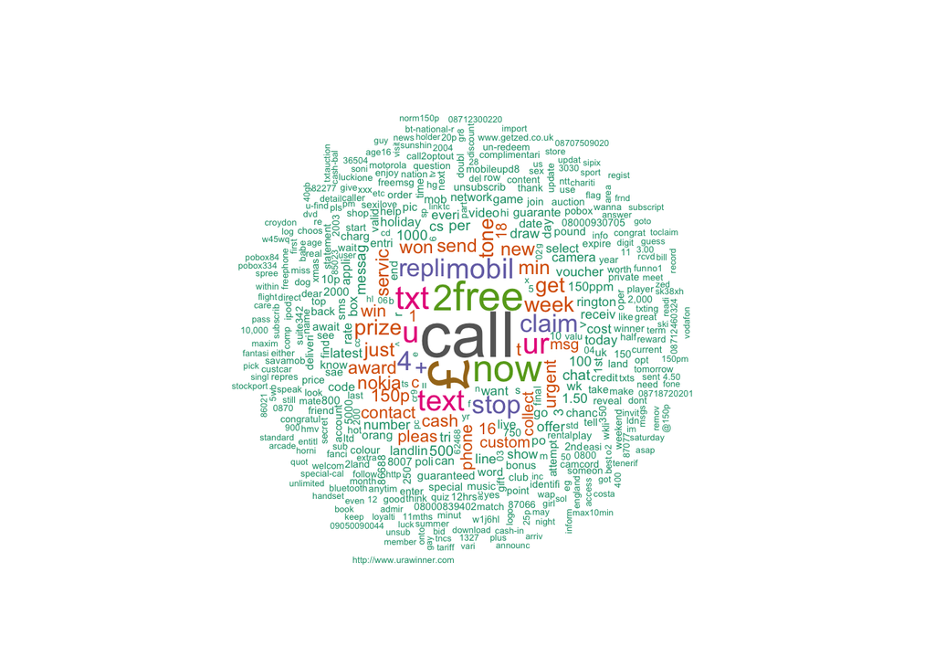

```r
library(quanteda.textplots)
library(RColorBrewer)
#we set a random seed for the cloud to be ordered always the same
set.seed(100)

textplot_wordcloud(only_spam_dfm, min_count = 6, random_order = FALSE,
                   rotation = .25,
                   colors = RColorBrewer::brewer.pal(8,"Dark2"))
```

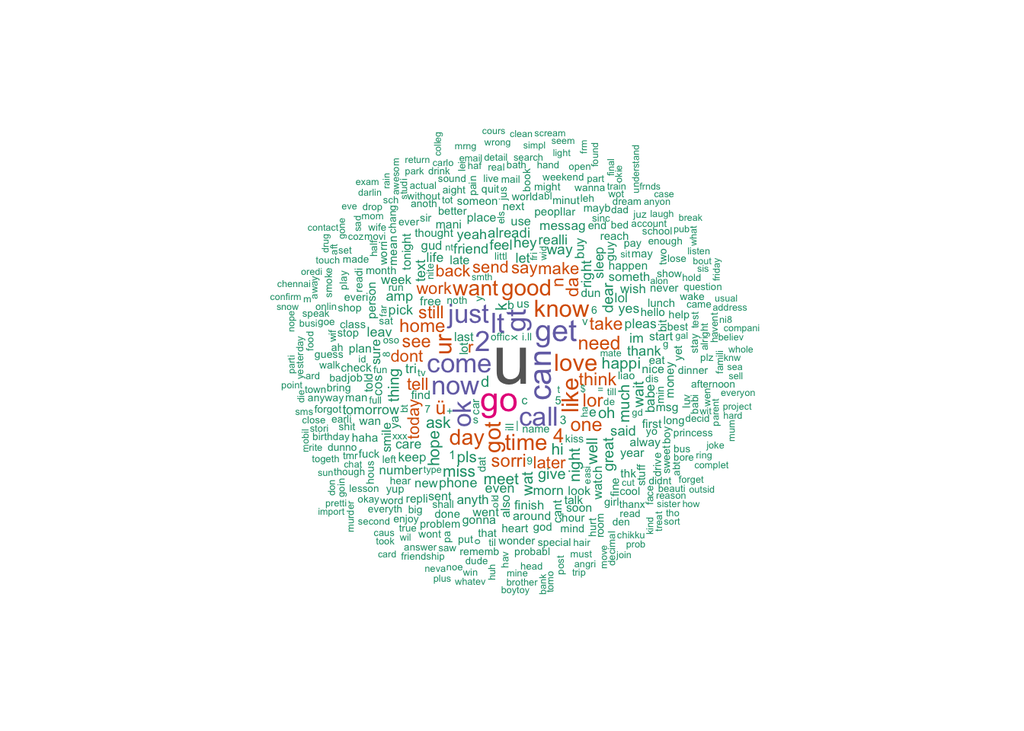

```r
library(quanteda.textplots)
library(RColorBrewer)
#we set a random seed for the cloud to be ordered always the same
set.seed(100)

textplot_wordcloud(only_ham_dfm, min_count = 6, random_order = FALSE,
                   rotation = .25,
                   colors = RColorBrewer::brewer.pal(8,"Dark2"))
```

## Summary

We have learned so far:

- How a document-term matrix works
- How to convert from tidytext to DTM
- How to use DTMs and DFMs to inspect word frequencies
- How to use `tm` library corpus objects
- How to use `quanteda` library corpus objects
- How to change from corpus objects to DTMs
- And back to tidy again